# Lecture 8: Building Functions

October 31, 2017

## R Functions are objects

R is a functional programming language. This means that functions are "objects", just like data frames, vectors, and other things that are assigned to variables and passed to other functions.

## A rose by any other name

```r
log
```

```
## function (x, base = exp(1))  .Primitive("log")
```

This means that we can create a copy of a function by assigning its value to a new variable.

```r
myLogFunction <- log
myLogFunction
```

```
## function (x, base = exp(1))  .Primitive("log")
```

## Functions are a kind of data and have a class

```r
myNumber <- 7
class(myNumber)
```

```
## [1] "numeric"
```

```r
class(log)
```

```
## [1] "function"
```

## Creating a function

We can create a new function using the word "function" followed by the functions arguments and one or more R statements.

```r
myDumbFunction <- function() 42
myDumbFunction()
```

```
## [1] 42
```

## Creating a multi-statement function

If there is more than one statement in a function, they should be enclosed in curly brackets:

```r
doubleIt <- function(x) {
  myResult <- x * 2
  myResult
}
doubleIt(5)
```

```
## [1] 10
```

The last statement within the curly brackets will be the value returned by the function.

## Functions live in their own little world

Inside a function, variables that existed in your environment can be used and even changed. However, any changes made, including changing data stored in variables and creating new variables, happens solely within the function. Your environment stays the same.

```r
exists("myResult")
```

[output not shown]

```r
myResult <- 1000
doubleItOutput <- doubleIt(2)
myResult
```

```
## [1] 1000
```

## Example Data Set

The data set used in today's lecture comes from an siRNA screen that we published a few years ago. The screen looked for genes that influence parkin translocation.

**High-content genome-wide RNAi screens identify regulators of parkin upstream of mitophagy.** Hasson SA, Kane LA, Yamano K, Huang CH, Sliter DA, Buehler E, Wang C, Heman-Ackah SM, Hessa T, Guha R, Martin SE, Youle RJ. Nature. 2013.

The data set will be available for download from the lectures portion of the class web page.

## Preview the Data

[figure not shown]

## Import the data

```r
ambion <- read.csv("lecture9_files/nature.parkin.gw.ambion.csv", stringsAsFactors = FALSE)
str(ambion)
```

```
## 'data.frame':    65196 obs. of  25 variables:
##  $ Vendor.Supplied.Gene.Symbol                                            : chr  "LMAN1" "MED15" "PFN2" "KIAA1191" ...
##  $ Sample                                                                 : num  8.91 7.92 7.97 11.2 8.88 ...
##  $ Median.Negative.Control.on.Plate                                       : num  38.6 33.3 31.4 43.8 34.3 ...
##  $ Median.Positive.Control.on.Plate                                       : num  96.7 96.7 97.1 96.5 96.1 ...
##  $ PPT.Sample.as.Percentage.of.Negative.Control                           : num  23.1 23.7 25.4 25.6 25.9 ...
##  $ PPT.MAD.Z.Score                                                        : num  -2.42 -2.4 -2.36 -2.35 -2.35 ...
##  $ PPT.MAD.Log.MAD.Z.Score                                                : num  -4.82 -4.74 -4.54 -4.52 -4.49 ...
##  $ Median.PPT.Log.Mad.Z.Score.for.all.siRNAs.having.the.same.seed.sequence: num  -2.056 -1.421 -1.421 -1.388 -0.485 ...
##  $ Number.of.siRNAs.having.the.same.seed.sequence                         : int  23 152 152 28 18 28 152 28 75 18 ...
##  $ Cell.Count..Sample                                                     : int  1286 1203 1177 1060 1272 1093 1170 854 1220 1136 ...
##  $ Median.Negative.Control.Cell.Count.on.Plate                            : num  1278 1310 1260 1344 1256 ...
##  $ Median.Positive.Control.Cell.Count.on.Plate                            : num  1030 1050 978 1106 985 ...
##  $ Sample.Cell.Count..MAD.Z.Score.Normalized.to.Negative.Contol           : num  1.109 0.241 0.399 -1.027 1.168 ...
##  $ Sample.1                                                               : num  8.94 16.79 11.3 11.13 12.89 ...
##  $ Median.Negative.Control.Mitophagy.on.Plate                             : num  10.7 28.1 29 15.5 12.1 ...
##  $ Median.Positive.Control.Mitophagy.on.Plate                             : num  22.4 49 50.1 27.7 22 ...
##  $ Sample.Mitophagy..MAD.Z.Score.Normalized.to.Negative.Control           : num  0.0466 -0.8887 -1.7 -0.4281 0.9416 ...
##  $ HUGO.Gene.Symbol                                                       : chr  "LMAN1" "PCQAP" "PFN2" "KIAA1191" ...
##  $ Entrez.GeneID                                                          : int  3998 51586 5217 57179 284221 650689 3998 374986 146723 90378 ...
##  $ REFSEQ                                                                 : chr  "NM_005570" "NM_001003891" "NM_002628" "NM_001079684" ...
##  $ DESCRIPTION                                                            : chr  "lectin, mannose-binding, 1" "mediator complex subunit 15" "profilin 2" "KIAA1191" ...
##  $ PLATE.ID                                                               : chr  "QDA101771" "QDA101996" "QDA103288" "QDA103435" ...
##  $ Row.Number                                                             : int  1 15 14 16 1 2 1 16 10 1 ...
##  $ Column.Number                                                          : int  4 21 19 11 12 1 4 16 1 14 ...
##  $ Ambion.siRNA.ID                                                        : chr  "s8218" "s28366" "s10379" "s226909" ...
```

## Check for missing data

```r
apply(ambion, 2, function(x) sum(is.na(x)))
```

```
##                                             Vendor.Supplied.Gene.Symbol
##                                                                       0
##                                                                  Sample
##                                                                     441
##                                        Median.Negative.Control.on.Plate
##                                                                     441
##                                        Median.Positive.Control.on.Plate
##                                                                     441
##                            PPT.Sample.as.Percentage.of.Negative.Control
##                                                                     441
##                                                         PPT.MAD.Z.Score
##                                                                     441
##                                                 PPT.MAD.Log.MAD.Z.Score
##                                                                     441
## Median.PPT.Log.Mad.Z.Score.for.all.siRNAs.having.the.same.seed.sequence
##                                                                     441
##                          Number.of.siRNAs.having.the.same.seed.sequence
##                                                                     441
##                                                      Cell.Count..Sample
##                                                                     441
##                             Median.Negative.Control.Cell.Count.on.Plate
##                                                                     441
##                             Median.Positive.Control.Cell.Count.on.Plate
##                                                                     441
##            Sample.Cell.Count..MAD.Z.Score.Normalized.to.Negative.Contol
##                                                                     441
##                                                                Sample.1
##                                                                     441
##                              Median.Negative.Control.Mitophagy.on.Plate
##                                                                     441
##                              Median.Positive.Control.Mitophagy.on.Plate
##                                                                     441
##            Sample.Mitophagy..MAD.Z.Score.Normalized.to.Negative.Control
##                                                                     441
##                                                        HUGO.Gene.Symbol
##                                                                       0
##                                                           Entrez.GeneID
##                                                                     441
##                                                                  REFSEQ
##                                                                       0
##                                                             DESCRIPTION
##                                                                       0
##                                                                PLATE.ID
##                                                                       0
##                                                              Row.Number
##                                                                     441
##                                                           Column.Number
##                                                                     441
##                                                         Ambion.siRNA.ID
##                                                                       0
```

## Investigate Missing Data

```r
ambion[is.na(ambion[,1]),][1,]
```

```
##    Vendor.Supplied.Gene.Symbol Sample Median.Negative.Control.on.Plate
## NA                        <NA>     NA                               NA
##    Median.Positive.Control.on.Plate
## NA                               NA
##    PPT.Sample.as.Percentage.of.Negative.Control PPT.MAD.Z.Score
## NA                                           NA              NA
##    PPT.MAD.Log.MAD.Z.Score
## NA                      NA
##    Median.PPT.Log.Mad.Z.Score.for.all.siRNAs.having.the.same.seed.sequence
## NA                                                                      NA
##    Number.of.siRNAs.having.the.same.seed.sequence Cell.Count..Sample
## NA                                             NA                 NA
##    Median.Negative.Control.Cell.Count.on.Plate
## NA                                          NA
##    Median.Positive.Control.Cell.Count.on.Plate
## NA                                          NA
##    Sample.Cell.Count..MAD.Z.Score.Normalized.to.Negative.Contol Sample.1
## NA                                                           NA       NA
##    Median.Negative.Control.Mitophagy.on.Plate
## NA                                         NA
##    Median.Positive.Control.Mitophagy.on.Plate
## NA                                         NA
##    Sample.Mitophagy..MAD.Z.Score.Normalized.to.Negative.Control
## NA                                                           NA
##    HUGO.Gene.Symbol Entrez.GeneID REFSEQ DESCRIPTION PLATE.ID Row.Number
## NA             <NA>            NA   <NA>        <NA>     <NA>         NA
##    Column.Number Ambion.siRNA.ID
## NA            NA            <NA>
```

## Eliminate Missing Data

```r
ambion <- ambion[! is.na(ambion[,2]), ]
apply(ambion, 2, function(x) sum(is.na(x)))
```

```
##                                             Vendor.Supplied.Gene.Symbol
##                                                                       0
##                                                                  Sample
##                                                                       0
##                                        Median.Negative.Control.on.Plate
##                                                                       0
##                                        Median.Positive.Control.on.Plate
##                                                                       0
##                            PPT.Sample.as.Percentage.of.Negative.Control
##                                                                       0
##                                                         PPT.MAD.Z.Score
##                                                                       0
##                                                 PPT.MAD.Log.MAD.Z.Score
##                                                                       0
## Median.PPT.Log.Mad.Z.Score.for.all.siRNAs.having.the.same.seed.sequence
##                                                                       0
##                          Number.of.siRNAs.having.the.same.seed.sequence
##                                                                       0
##                                                      Cell.Count..Sample
##                                                                       0
##                             Median.Negative.Control.Cell.Count.on.Plate
##                                                                       0
##                             Median.Positive.Control.Cell.Count.on.Plate
##                                                                       0
##            Sample.Cell.Count..MAD.Z.Score.Normalized.to.Negative.Contol
##                                                                       0
##                                                                Sample.1
##                                                                       0
##                              Median.Negative.Control.Mitophagy.on.Plate
##                                                                       0
##                              Median.Positive.Control.Mitophagy.on.Plate
##                                                                       0
##            Sample.Mitophagy..MAD.Z.Score.Normalized.to.Negative.Control
##                                                                       0
##                                                        HUGO.Gene.Symbol
##                                                                       0
##                                                           Entrez.GeneID
##                                                                       0
##                                                                  REFSEQ
##                                                                       0
##                                                             DESCRIPTION
##                                                                       0
##                                                                PLATE.ID
##                                                                       0
##                                                              Row.Number
##                                                                       0
##                                                           Column.Number
##                                                                       0
##                                                         Ambion.siRNA.ID
##                                                                       0
```

## Simplify the Data

Often it will be helpful to create a new data frame with only the data we wish to analyze.

```r
ambion.simple <- ambion[,c(19,25,1,21,7,13,17)]
ambion.simple[1,]
```

```
##   Entrez.GeneID Ambion.siRNA.ID Vendor.Supplied.Gene.Symbol
## 1          3998           s8218                       LMAN1
##                  DESCRIPTION PPT.MAD.Log.MAD.Z.Score
## 1 lectin, mannose-binding, 1                -4.82223
##   Sample.Cell.Count..MAD.Z.Score.Normalized.to.Negative.Contol
## 1                                                     1.108518
##   Sample.Mitophagy..MAD.Z.Score.Normalized.to.Negative.Control
## 1                                                   0.04662911
```

## Simplify our Column Names

```r
library(knitr, quietly = TRUE)
colnames(ambion.simple) <- c("GeneID","siRNA","Symbol","Description",
                             "PPT","Cells","Mitophagy")
kable(head(ambion.simple, n=4), format = "markdown")
```

| GeneID | siRNA | Symbol | Description | PPT | Cells | Mitophagy |
| --- | --- | --- | --- | --- | --- | --- |
| 3998 | s8218 | LMAN1 | lectin, mannose-binding, 1 | -4.822230 | 1.1085178 | 0.0466291 |
| 51586 | s28366 | MED15 | mediator complex subunit 15 | -4.739415 | 0.2405872 | -0.8887362 |
| 5217 | s10379 | PFN2 | profilin 2 | -4.539309 | 0.3994161 | -1.7000123 |
| 57179 | s226909 | KIAA1191 | KIAA1191 | -4.516443 | -1.0274124 | -0.4280631 |

## Evaluate how our variables interact

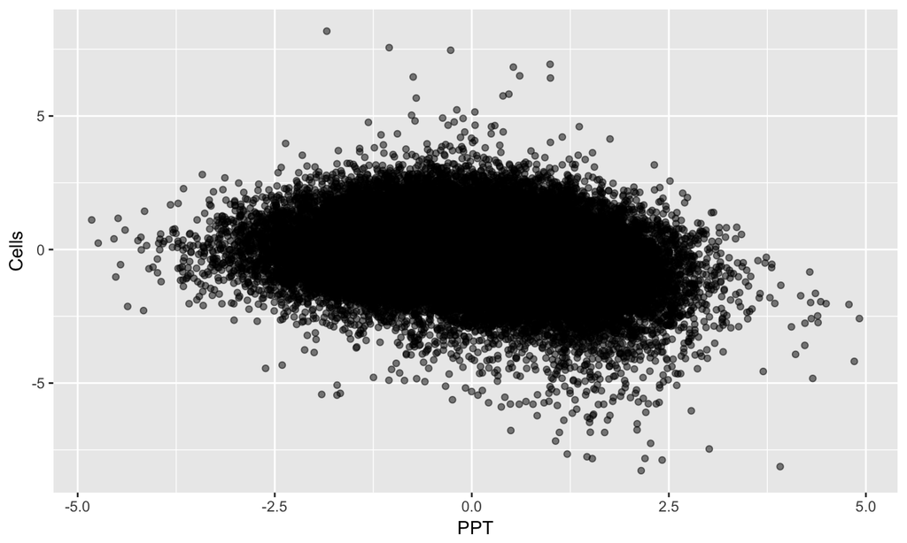

```r
library(ggplot2, quietly = TRUE)
ggplot(ambion.simple, aes(x=PPT, y=Cells)) + geom_point(alpha=0.5)
```

## Evaluate how our variables interact

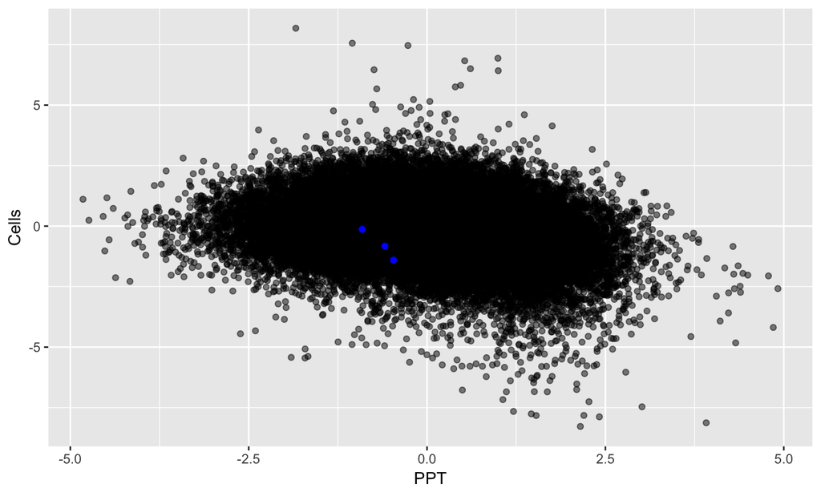

```r
ggplot(ambion.simple, aes(x=PPT, y=Cells)) + geom_point(alpha=0.5) +
    geom_point(data = ambion.simple[ambion.simple$Symbol == "PARK2",],
               color="blue")
```

## Refine the plot

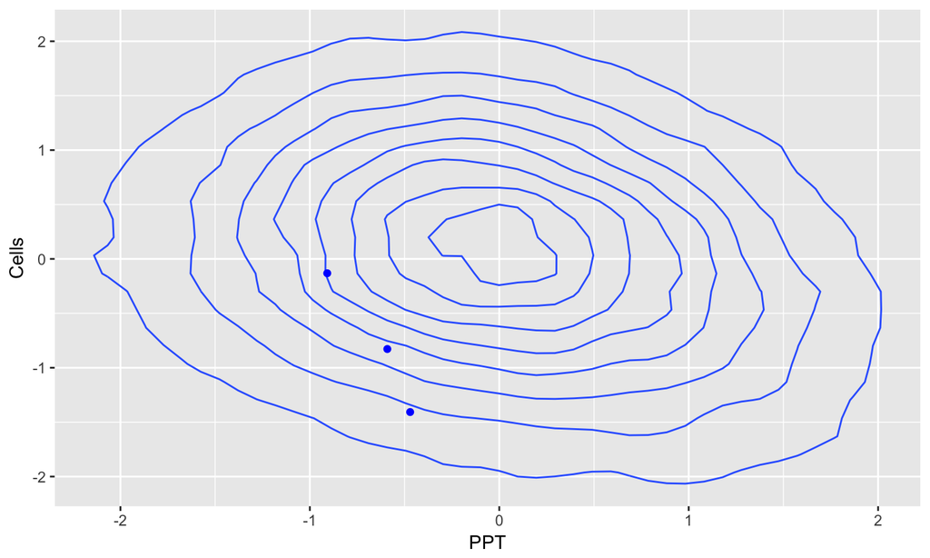

```r
ggplot(ambion.simple, aes(x=PPT, y=Cells)) + geom_density2d() +
    geom_point(data = ambion.simple[ambion.simple$Symbol == "PARK2",],
               color="blue")
```

## Further refine the plot

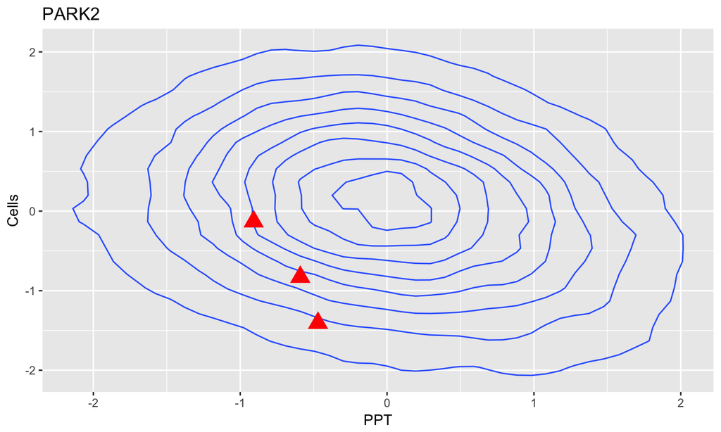

```r
ggplot(ambion.simple, aes(x=PPT, y=Cells)) + geom_density2d() +
    geom_point(data = ambion.simple[ambion.simple$Symbol == "PARK2",],
               color="red", shape=17, size =5) +
        ggtitle("PARK2")
```

## Adding gene description

```r
description <- ambion.simple$Description[ambion.simple$Symbol == "PARK2"][1]
description
```

```
## [1] "Parkinson disease (autosomal recessive, juvenile) 2, parkin"
```

```r
myTitle <- paste("PARK2",description,sep=": ")
myTitle
```

```
## [1] "PARK2: Parkinson disease (autosomal recessive, juvenile) 2, parkin"
```

## Final version of plot

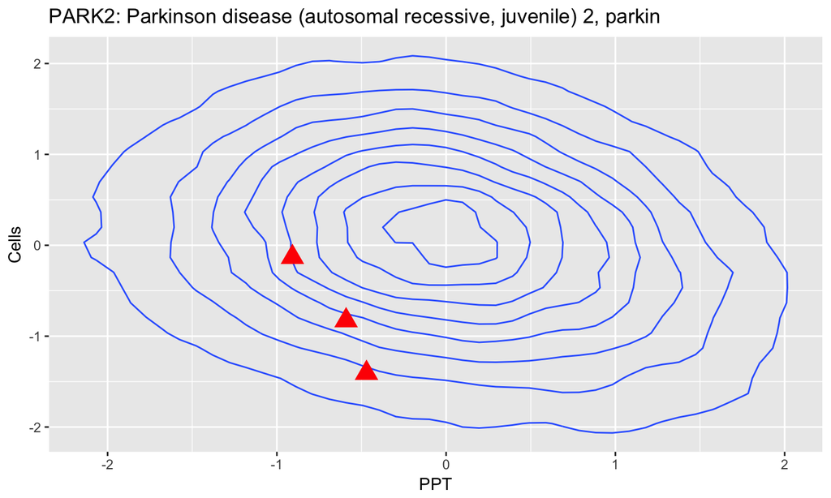

```r
ggplot(ambion.simple, aes(x=PPT, y=Cells)) + geom_density2d() +
    geom_point(data = ambion.simple[ambion.simple$Symbol == "PARK2",],
               color="red", shape=17, size =5) +
        ggtitle(myTitle)
```

## Making the refined plot into a function

Now that we have our custom plot looking right, we would like to be able to do the same for other genes but without so much typing. First, make a new R Script in RStudio:

[figure not shown]

## Constructing a new function from your history

Frequently, making a function will simply be a function of selecting the right parts of your history and hitting the "to source" button.

[figure not shown]

## Function with PARK2 hard coded

```r
graphGene <- function(gene) {
  description <- ambion.simple$Description[ambion.simple$Symbol == "PARK2"][1]
  myTitle <- paste("PARK2",description,sep=": ")
  ggplot(ambion.simple, aes(x=PPT, y=Cells)) + geom_density2d() +
    geom_point(data = ambion.simple[ambion.simple$Symbol == "PARK2",],
               color="red", shape=17, size =5) +
    ggtitle(myTitle)
}
```

## Function made generic

```r
graphGene <- function(gene) {
  description <- ambion.simple$Description[ambion.simple$Symbol == gene][1]
  myTitle <- paste(gene,description,sep=": ")
  ggplot(ambion.simple, aes(x=PPT, y=Cells)) + geom_density2d() +
    geom_point(data = ambion.simple[ambion.simple$Symbol == gene,],
               color="red", shape=17, size =5) +
    ggtitle(myTitle)
}
```

## Our function in action

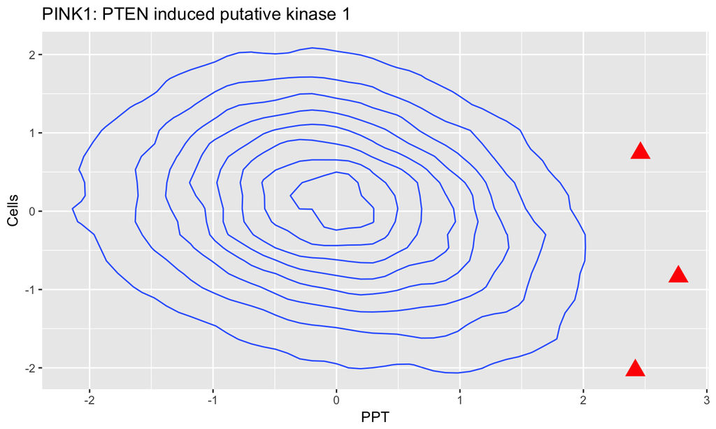

```r
graphGene("PINK1")
```

## Default values for function arguments

```r
pdfGene <- function(gene, file=paste(gene,".pdf", sep="")) {
    pdf(file, width=5, height=5)
    graphGene(gene)
    dev.off()
}
```

## Passing on extra arguments to our function

We can use the ellipse notation (…) to indicate that extra arguments to our function should be passed on to a function that is inside our function (in this case pdf).

```r
pdfGene <- function(gene, file=paste(gene,".pdf", sep=""), ...) {
    pdf(file, ...)
    graphGene(gene)
    dev.off()
}
pdfGene("PINK1", width=10, height=10)
```

## Control of Flow: If/Else

We can decide whether something happens in our function using "if" and "if/else".

```r
sillyFunction <- function(x) {
  if (x < 5) {
    returnValue <- x
  }
  else {
    returnValue <- x / 2
  }
  returnValue
}
sillyFunction(12)
```

```
## [1] 6
```

## Control of Flow: For

```r
pdfGenes <- function(genes, file=paste(gene,".pdf", sep=""), ...) {
    pdf(file, ...)
    for (gene in genes) {
      graphGene(gene)
    }
    dev.off()
}
pdfGenes(c("PLK1","PINK1","BRCA1"))
```